# DNN_CNN

```python
import pandas as pd
import os
from PIL import Image, UnidentifiedImageError
import numpy as np
from concurrent.futures import ThreadPoolExecutor
json_file = 'C:/Users/user/Documents/yelp_photos/photos.json'
df = pd.read_json(json_file, lines=True, nrows=1000)
label_mapping = df[['photo_id', 'label']]
image_folder = 'C:/Users/user/Documents/yelp_photos/photos'
def process_image(row):
    photo_id = row['photo_id']
    label = row['label']
    image_path = os.path.join(image_folder, f"{photo_id}.jpg")
    if not os.path.exists(image_path):
        return None, None
    try:
        img = Image.open(image_path)
        img = img.resize((224, 224))
        img_array = np.array(img) / 255.0
        return img_array, label
    except UnidentifiedImageError:
        return None, None
    except Exception as e:
        print(f"Error loading image for photo_id: {photo_id}. Error: {e}")
        return None, None
images = []
preprocessed_labels = []
with ThreadPoolExecutor() as executor:
    results = list(executor.map(process_image, label_mapping.to_dict('records')))
#Using this to maintain the shape
for img_array, label in results:
    if img_array is not None and label is not None:
        images.append(img_array)
        preprocessed_labels.append(label)
final_df = pd.DataFrame({
    'photo_id': label_mapping['photo_id'].iloc[:len(images)].values,
    'label': preprocessed_labels,
    'image': images
})
print(final_df.head())
```

```
                 photo_id    label  \
0  zsvj7vloL4L5jhYyPIuVwg   inside
1  HCUdRJHHm_e0OCTlZetGLg  outside
2  vkr8T0scuJmGVvN2HJelEA    drink
3  pve7D6NUrafHW3EAORubyw     food
4  H52Er-uBg6rNrHcReWTD2w     food

                                               image
0  [[[0.15294117647058825, 0.06666666666666667, 0...
1  [[[0.8313725490196079, 0.8980392156862745, 0.9...
2  [[[0.4980392156862745, 0.28627450980392155, 0....
3  [[[0.12941176470588237, 0.10588235294117647, 0...
4  [[[0.6274509803921569, 0.6627450980392157, 0.7...
```

[figure not shown]

[figure not shown]

[figure not shown]

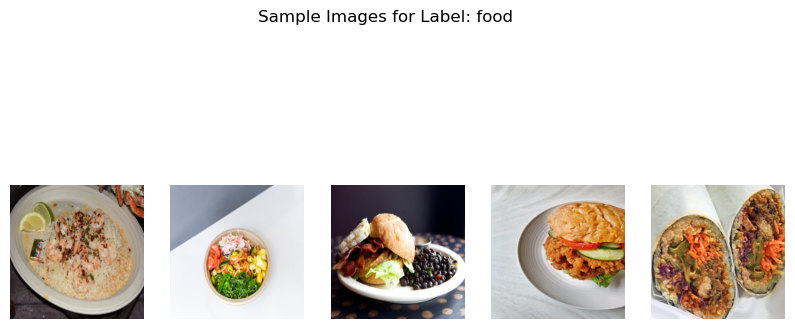

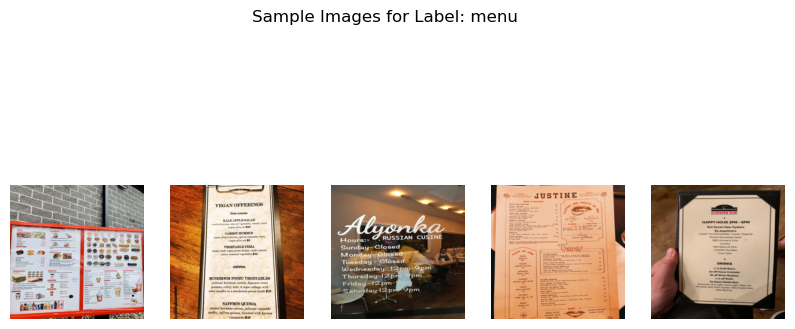

```python
def plot_sample_images(label, num_images=5):
    sample_images = final_df[final_df['label'] == label]['image'].head(num_images)
    plt.figure(figsize=(10, 5))
    for i, img_array in enumerate(sample_images):
        plt.subplot(1, num_images, i+1)
        plt.imshow(img_array)
        plt.axis('off')
    plt.suptitle(f'Sample Images for Label: {label}')
    plt.show()
# Plot sample images for each label
for label in final_df['label'].unique():
    plot_sample_images(label)
```

Here we have imported and loaded the images from the dataset.

```python
missing_labels = final_df['label'].isnull().sum()
print(f'Missing Labels: {missing_labels}')
missing_images = final_df['image'].isnull().sum()
print(f'Missing Images: {missing_images}')
```

```
Missing Labels: 0
Missing Images: 0
```

Check if there are any missing images and lables of the images missing.

```python
image_shapes = [img.shape for img in final_df['image']]
unique_shapes = set(image_shapes)
print(f"Unique image shapes: {unique_shapes}")

image_data = np.array([img.flatten() for img in final_df['image']])
mean_pixel_value = np.mean(image_data)
std_pixel_value = np.std(image_data)
print(f"Mean pixel value: {mean_pixel_value}")
print(f"Standard deviation of pixel values: {std_pixel_value}")
```

```
Unique image shapes: {(224, 224, 3)}
Mean pixel value: 0.4575029893988837
Standard deviation of pixel values: 0.30301191848536047
```

Checking the shape of the images and calculating the mean and the standard deviationof the pixel values.

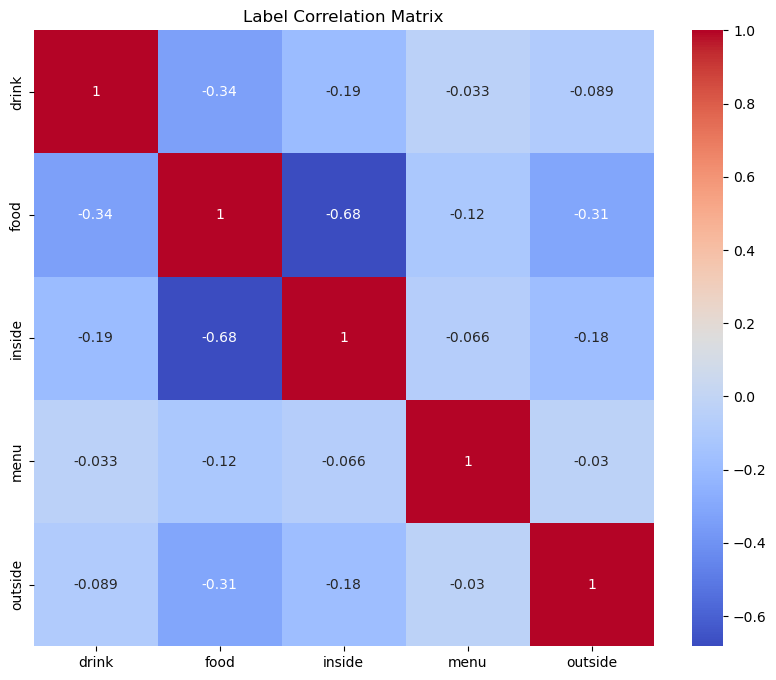

```python
label_mapping_numerical = pd.get_dummies(final_df['label'])
corr_matrix = label_mapping_numerical.corr()
plt.figure(figsize=(10,8))
sns.heatmap(corr_matrix, annot=True, cmap='coolwarm')
plt.title('Label Correlation Matrix')
plt.show()
```

Plotted the corrrelationnmatrix to gather the info if the multiple image classes are correlated with eachother or not. from the above matrix we can see that features are negetively correlated with eachother saying there is no relation with eachother.

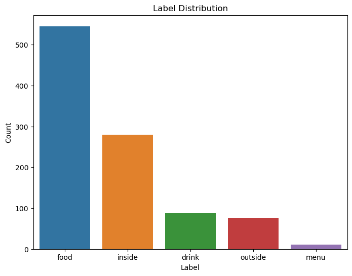

```python
label_distribution = final_df['label'].value_counts()
plt.figure(figsize=(8,6))
sns.barplot(x=label_distribution.index, y=label_distribution.values)
plt.title('Label Distribution')
plt.xlabel('Label')
plt.ylabel('Count')
plt.show()
```

plotted the bar plot to understand the data in each class where the data for food is more compared to others.

```python
final_df['label'].value_counts()
```

```
food       545
inside     280
drink       88
outside     76
menu        11
Name: label, dtype: int64
```

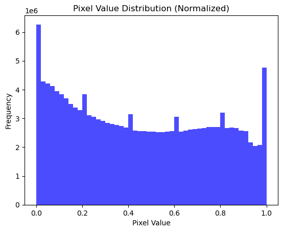

```python
pixel_values = np.concatenate([img.flatten() for img in final_df['image']])
plt.hist(pixel_values, bins=50, color='blue', alpha=0.7)
plt.title('Pixel Value Distribution (Normalized)')
plt.xlabel('Pixel Value')
plt.ylabel('Frequency')
plt.show()
```

```python
final_df['image'].head(5)
```

```
0    [[[0.15294117647058825, 0.06666666666666667, 0...
1    [[[0.8313725490196079, 0.8980392156862745, 0.9...
2    [[[0.4980392156862745, 0.28627450980392155, 0....
3    [[[0.12941176470588237, 0.10588235294117647, 0...
4    [[[0.6274509803921569, 0.6627450980392157, 0.7...
Name: image, dtype: object
```

here we have flattened the pixel values of the image for the model training.

```python
import numpy as np
import pandas as pd
from sklearn.model_selection import train_test_split
from sklearn.preprocessing import OneHotEncoder
from keras.models import Sequential
from keras.layers import Dense, Flatten, Dropout
from keras.callbacks import EarlyStopping
from sklearn.utils import class_weight
```

```python
X = np.array(images)
y = np.array(preprocessed_labels)
```

```python
encoder = OneHotEncoder(sparse_output=False)
y_encoded= encoder.fit_transform(y.reshape(-1, 1))
```

```python
X_train, X_test, y_train, y_test = train_test_split(X, y_encoded, test_size=0.2, random_state=42)
```

considering 80% of the data for training and the 20% of the data for test.

```python
def create_dnn(input_shape):
    model = Sequential()
    model.add(Flatten(input_shape=input_shape))
    model.add(Dense(128, activation='relu'))
    model.add(Dropout(0.5))
    model.add(Dense(64, activation='relu'))
    model.add(Dropout(0.5))
    model.add(Dense(y_encoded.shape[1], activation='softmax'))
    model.compile(optimizer='adam', loss='categorical_crossentropy', metrics=['accuracy'])
    return model
```

```python
dnn_model = create_dnn((224, 224, 3))
early_stopping = EarlyStopping(monitor='val_loss', patience=3)
dnn_history = dnn_model.fit(X_train, y_train, validation_data=(X_test, y_test), epochs=10, batch_size=32, callbacks=[early_stopping])
```

```
25/25 ━━━━━━━━━━━━━━━━━━━━ 16s 383ms/step - accuracy: 0.3120 - loss: 37.3424 - val_accuracy: 0.2850 - val_loss: 1.5901
25/25 ━━━━━━━━━━━━━━━━━━━━ 5s 207ms/step - accuracy: 0.2962 - loss: 1.6071 - val_accuracy: 0.5700 - val_loss: 1.5507
25/25 ━━━━━━━━━━━━━━━━━━━━ 5s 193ms/step - accuracy: 0.4972 - loss: 1.5412 - val_accuracy: 0.5700 - val_loss: 1.5086
25/25 ━━━━━━━━━━━━━━━━━━━━ 5s 197ms/step - accuracy: 0.5058 - loss: 1.9426 - val_accuracy: 0.5700 - val_loss: 1.4710
25/25 ━━━━━━━━━━━━━━━━━━━━ 5s 198ms/step - accuracy: 0.5320 - loss: 1.4754 - val_accuracy: 0.5700 - val_loss: 1.4376
25/25 ━━━━━━━━━━━━━━━━━━━━ 5s 194ms/step - accuracy: 0.5374 - loss: 1.4625 - val_accuracy: 0.5700 - val_loss: 1.4071
25/25 ━━━━━━━━━━━━━━━━━━━━ 5s 198ms/step - accuracy: 0.5453 - loss: 1.4158 - val_accuracy: 0.5700 - val_loss: 1.3794
25/25 ━━━━━━━━━━━━━━━━━━━━ 5s 205ms/step - accuracy: 0.5382 - loss: 1.3890 - val_accuracy: 0.5700 - val_loss: 1.3543
25/25 ━━━━━━━━━━━━━━━━━━━━ 6s 227ms/step - accuracy: 0.5307 - loss: 1.3680 - val_accuracy: 0.5700 - val_loss: 1.3308
25/25 ━━━━━━━━━━━━━━━━━━━━ 5s 197ms/step - accuracy: 0.5381 - loss: 1.3606 - val_accuracy: 0.5700 - val_loss: 1.3091
```

As we can see as we increase the epochs the loss is decreased and the accuracy got up to 53% which is descent.

```python
from sklearn.metrics import roc_curve, auc
import matplotlib.pyplot as plt
dnn_predictions = dnn_model.predict(X_test)
dnn_fpr, dnn_tpr, _ = roc_curve(y_test.ravel(), dnn_predictions.ravel())
dnn_auc = auc(dnn_fpr, dnn_tpr)
```

[output not shown]

```python
def create_cnn(input_shape):
    model = Sequential()
    model.add(Conv2D(32, (3, 3), activation='relu', input_shape=input_shape))
    model.add(MaxPooling2D(pool_size=(2, 2)))
    model.add(Conv2D(64, (3, 3), activation='relu'))
    model.add(MaxPooling2D(pool_size=(2, 2)))
    model.add(Flatten())
    model.add(Dense(128, activation='relu'))
    model.add(Dropout(0.5))
    model.add(Dense(y_encoded.shape[1], activation='softmax'))  # Use softmax for multi-class
    model.compile(optimizer='adam', loss='categorical_crossentropy', metrics=['accuracy'])
    return model
```

```python
# Create and train the CNN
cnn_model = create_cnn((224, 224, 3))
cnn_history = cnn_model.fit(X_train, y_train, validation_data=(X_test, y_test), epochs=10, batch_size=32, callbacks=[EarlyStopping(patience=3)])
```

```
25/25 ━━━━━━━━━━━━━━━━━━━━ 27s 933ms/step - accuracy: 0.4011 - loss: 5.9475 - val_accuracy: 0.7000 - val_loss: 0.9589
25/25 ━━━━━━━━━━━━━━━━━━━━ 19s 758ms/step - accuracy: 0.6530 - loss: 0.9892 - val_accuracy: 0.7050 - val_loss: 0.8511
25/25 ━━━━━━━━━━━━━━━━━━━━ 20s 752ms/step - accuracy: 0.7315 - loss: 0.7884 - val_accuracy: 0.7200 - val_loss: 0.7773
25/25 ━━━━━━━━━━━━━━━━━━━━ 20s 774ms/step - accuracy: 0.8168 - loss: 0.5585 - val_accuracy: 0.7200 - val_loss: 0.8344
25/25 ━━━━━━━━━━━━━━━━━━━━ 19s 741ms/step - accuracy: 0.8688 - loss: 0.3958 - val_accuracy: 0.7300 - val_loss: 0.7822
25/25 ━━━━━━━━━━━━━━━━━━━━ 19s 750ms/step - accuracy: 0.9205 - loss: 0.2751 - val_accuracy: 0.7000 - val_loss: 0.8401
```

As we know CNN is good for image data whivh we can already notice from the bove accuracy which is 92% got up from 40% in first wpoch and the loss has decreased significantly comoared to DNN.

```python
cnn_predictions = cnn_model.predict(X_test)
cnn_fpr, cnn_tpr, _ = roc_curve(y_test.ravel(), cnn_predictions.ravel())
cnn_auc = auc(cnn_fpr, cnn_tpr)
```

```
7/7 ━━━━━━━━━━━━━━━━━━━━ 2s 219ms/step
```

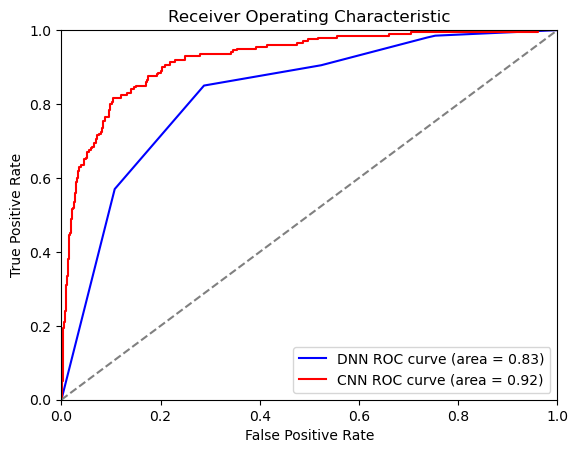

```python
plt.figure()
plt.plot(dnn_fpr, dnn_tpr, color='blue', label='DNN ROC curve (area = {:.2f})'.format(dnn_auc))
plt.plot(cnn_fpr, cnn_tpr, color='red', label='CNN ROC curve (area = {:.2f})'.format(cnn_auc))
plt.plot([0, 1], [0, 1], color='gray', linestyle='--')
plt.xlim([0.0, 1.0])
plt.ylim([0.0, 1.0])
plt.xlabel('False Positive Rate')
plt.ylabel('True Positive Rate')
plt.title('Receiver Operating Characteristic')
plt.legend(loc='lower right')
plt.show()
```

We can see form the ROC that CNN in red is predicting good compared to that of the DNN. CNN curve is close to top left corner close 1 i.e., 92 where as DNN is 83.

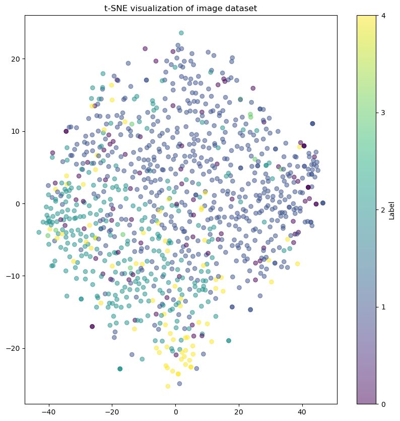

```python
from sklearn.decomposition import PCA
from sklearn.manifold import TSNE

images = np.array(final_df['image'].tolist())
flattened_images =images.reshape(images.shape[0], -1)

pca = PCA(n_components=50)
pca_result = pca.fit_transform(flattened_images)

tsne = TSNE(n_components=2, random_state=42)
tsne_result = tsne.fit_transform(pca_result)
plt.figure(figsize=(10, 10))
plt.scatter(tsne_result[:, 0], tsne_result[:, 1], c=final_df['label'].astype('category').cat.codes, cmap='viridis', alpha=0.5)
plt.title('t-SNE visualization of image dataset')
plt.colorbar(ticks=range(len(final_df['label'].unique())), label='Label')
plt.show()
```

[figure not shown]

```python
# Augmentation Analysis
from tensorflow.keras.preprocessing.image import ImageDataGenerator
import matplotlib.pyplot as plt
datagen = ImageDataGenerator(
    rotation_range=20,
    width_shift_range=0.2,
    height_shift_range=0.2,
    shear_range=0.2,
    zoom_range=0.2,
    horizontal_flip=True,
    fill_mode='nearest')
sample_image = np.expand_dims(images[0], axis=0)
augmented_images = datagen.flow(sample_image, batch_size=1)
plt.figure(figsize=(15, 6))
for i in range(5):
    plt.subplot(1, 5, i + 1)
    img = augmented_images[0][0][i]
    plt.imshow(img)
    plt.title(f'Augmented Image {i + 1}')
    plt.axis('off')
plt.tight_layout()
plt.show()
```

```python
import numpy as np
from tensorflow.keras.models import Sequential
from tensorflow.keras.layers import Dense
from tensorflow.keras.optimizers import Adam
from sklearn.model_selection import RandomizedSearchCV
from sklearn.base import BaseEstimator

from tensorflow.keras.layers import Flatten
class KerasDNN(BaseEstimator):
    def __init__(self, learning_rate=0.01, neurons=32, epochs=2, batch_size=5):
        self.learning_rate = learning_rate
        self.neurons = neurons
        self.epochs = epochs
        self.batch_size = batch_size
        self.model = None
    def create_model(self):
        model = Sequential()
        model.add(Dense(self.neurons, input_shape=(224, 224, 3), activation='relu'))
        model.add(Flatten())
        model.add(Dense(self.neurons, activation='relu'))
        model.add(Dense(5, activation='softmax'))
        model.compile(optimizer=Adam(learning_rate=self.learning_rate),
                      loss='categorical_crossentropy',
                      metrics=['accuracy'])
        return model
    def fit(self, X, y):
        self.model = self.create_model()
        self.model.fit(X, y, epochs=self.epochs, batch_size=self.batch_size, verbose=0)
    def predict(self, X):
        return self.model.predict(X)
    def score(self, X, y):
        _, accuracy = self.model.evaluate(X, y, verbose=0)
        return accuracy
dnn_model = KerasDNN()
param_grid = {
    'learning_rate': [0.1, 0.01],
    'neurons': [16,32],
    'batch_size': [2,3],
    'epochs': [1,2]
}
random_search = RandomizedSearchCV(estimator=dnn_model, param_distributions=param_grid, n_iter=2, cv=2)
random_search_result = random_search.fit(X_train, y_train)
print("Best DNN Hyperparameters: ", random_search_result.best_params_)
```

```
Best DNN Hyperparameters:  {'neurons': 16, 'learning_rate': 0.1, 'epochs': 2, 'batch_size': 2}
```

```python
print("Best Accuracy: ", round(random_search_result.best_score_,2))
```

```
Best Accuracy:  0.54
```

After tuning the best accuracy for the DNN model is 54% which is expected.

```python
def create_cnn(learning_rate=0.001, filters=32, kernel_size=(3, 3)):
    model = Sequential()
    model.add(Conv2D(filters, kernel_size, activation='relu', input_shape=(224, 224, 3)))
    model.add(MaxPooling2D(pool_size=(2, 2)))
    model.add(Flatten())
    model.add(Dense(64, activation='relu'))
    model.add(Dense(5, activation='softmax'))
    model.compile(optimizer=Adam(learning_rate=learning_rate),
                  loss='categorical_crossentropy',
                  metrics=['accuracy'])
    return model
```

```python
from sklearn.base import BaseEstimator
class KerasCNN(BaseEstimator):
    def __init__(self, learning_rate=0.001, filters=32, kernel_size=(3, 3), epochs=1, batch_size=2):
        self.learning_rate = learning_rate
        self.filters = filters
        self.kernel_size = kernel_size
        self.epochs = epochs
        self.batch_size = batch_size
        self.model = None
    def create_model(self):
        return create_cnn(self.learning_rate, self.filters, self.kernel_size)
    def fit(self, X, y):
        self.model = self.create_model()
        self.model.fit(X, y, epochs=self.epochs, batch_size=self.batch_size, verbose=0)
    def predict(self, X):
        return self.model.predict(X)
    def score(self, X, y):
        _, accuracy = self.model.evaluate(X, y, verbose=0)
        return accuracy
```

We used keras base estimator for hyper parameter tuning, set the learning rate, epochs, batch size.

```python
import numpy as np
from tensorflow.keras.models import Sequential
from tensorflow.keras.layers import Conv2D, MaxPooling2D, Flatten, Dense
from tensorflow.keras.optimizers import Adam
```

```python
from sklearn.model_selection import RandomizedSearchCV
cnn_model = KerasCNN()
param_grid = {
    'learning_rate': [0.01, 0.001],
    'filters': [16, 32],
    'kernel_size': [(3, 3)],
    'epochs': [1],
    'batch_size': [2]
}
random_search = RandomizedSearchCV(estimator=cnn_model, param_distributions=param_grid, n_iter=2, cv=2)
random_search_result = random_search.fit(X_train, y_train)
print("Best CNN Hyperparameters: ", random_search_result.best_params_)
```

[output not shown]

```python
print("Best CNN Accuracy:",round(random_search_result.best_score_,2))
```

```
Best CNN Accuracy: 0.61
```

The Accuracy reduced to 60% as the epoch was only one and batch size 2,The accuracy can be increased if these two are increased.

# Inferences: